# Plot segment-wise habitat changes and porpoise distribution gaps

Yi Han

2021-11-26

**Email**: yi.han.178@gmail.com  
**Description**: Plot the segment-wise porpoise abundance changes, changing trends of the floodplain area and cropland%, and urban development levels, which correspond to Fig. 2b.

## 1. Plot distribution gaps of the porpoise

We define a distribution gap of the porpoise as a river sections with extremely low porpoise abundance, i.e., < 0.05 porpoise per km, in both 2006 and 2017.

```r
seg_wise_abund_df <- read.csv(file="../02_percentage_coverage_of_PAs/segment_wise_porpoise_abundance.csv")
head(seg_wise_abund_df, 5)
```

|  | groups | f_year | year | abund_ranks | segment_mean | reserve | reserve_without_nj |
| --- | --- | --- | --- | --- | --- | --- | --- |
| 1 | [0,10) | 2006 | 2006 | [0,0.05) | 0 | N | N |
| 2 | [10,20) | 2006 | 2006 | [0,0.05) | 0 | N | N |
| 3 | [20,30) | 2006 | 2006 | [0,0.05) | 0 | N | N |
| 4 | [30,40) | 2006 | 2006 | [0,0.05) | 0 | N | N |
| 5 | [40,50) | 2006 | 2006 | [0,0.05) | 0 | N | N |

```r
group_levels <- seg_wise_abund_df$groups[1:150]
abund_df <- seg_wise_abund_df %>%
    dplyr::select(groups, year, segment_mean) %>%
    dplyr::mutate(groups = factor(groups, levels=group_levels)) %>%
    dplyr::mutate(group_levels = as.numeric(groups)) %>%
    tidyr::pivot_wider(., names_from = year, values_from = segment_mean) %>%
    dplyr::rename(abund_06 = "2006", abund_17 = "2017") %>%
    dplyr::mutate(abund_change = abund_17 - abund_06) %>%
    dplyr::filter(group_levels <= 145)
head(abund_df, 5)
```

| groups | group_levels | abund_06 | abund_17 | abund_change |
| --- | --- | --- | --- | --- |
| [0,10) | 1 | 0 | 0.0950 | 0.0950 |
| [10,20) | 2 | 0 | 0.0950 | 0.0950 |
| [20,30) | 3 | 0 | 0.0730 | 0.0730 |
| [30,40) | 4 | 0 | 0.0165 | 0.0165 |
| [40,50) | 5 | 0 | 0.0050 | 0.0050 |

```r
abund_df <- abund_df %>%
    mutate(dist_gap = case_when((abund_06 < 0.05 & abund_17 < 0.05) ~ "perm_gap",
                                (abund_06 >= 0.05 & abund_17 < 0.05) ~ "new_gap",
                                (abund_06 <= abund_17 & abund_17 >= 0.2) ~ "steady-recover",
                                (abund_06 >= 0.2 & abund_17 >= 0.2) ~ "consist high",
                                TRUE ~ "non-gap-non-high")) %>%
    mutate(dist_gap = factor(dist_gap, levels = c("perm_gap", "new_gap", "non-gap-non-high", "consist high", "steady-recover")))
head(abund_df, 5)
```

| groups | group_levels | abund_06 | abund_17 | abund_change | dist_gap |
| --- | --- | --- | --- | --- | --- |
| [0,10) | 1 | 0 | 0.0950 | 0.0950 | non-gap-non-high |
| [10,20) | 2 | 0 | 0.0950 | 0.0950 | non-gap-non-high |
| [20,30) | 3 | 0 | 0.0730 | 0.0730 | non-gap-non-high |
| [30,40) | 4 | 0 | 0.0165 | 0.0165 | perm_gap |
| [40,50) | 5 | 0 | 0.0050 | 0.0050 | perm_gap |

**Plot the distribution gaps**

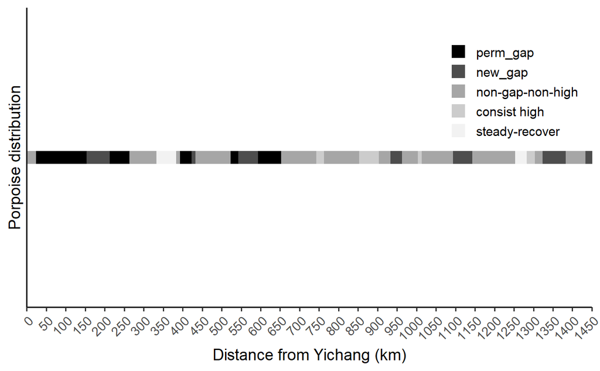

```r
abund_gap_plot <- ggplot(abund_df, aes(x=group_levels, y=1,
                                       color=dist_gap, fill=dist_gap)) +
    geom_point(shape=15, size=5)+
    scale_color_manual(values = c("black", "grey30", "grey65", "grey80", "grey95")) +
    scale_fill_manual(values = c("black", "grey30", "grey65", "grey80", "grey95")) +
    scale_x_continuous(expand = c(0, 0), limits = c(0, 145), breaks=seq(0, 145, 5),
                       labels = seq(0, 1450, 50)) +
    scale_y_continuous(expand = c(0, 1), limits = NULL, breaks = NULL) +
    labs(x = "Distance from Yichang (km)",
         y = "Porpoise distribution") +
    guides(fill=guide_legend(""), color=guide_legend("")) +
    theme_classic(base_size = 14) +
    theme(axis.text.x = element_text(angle = 45, hjust = 1),
          legend.position = c(.99, .99),
          legend.justification = c("right", "top"),
          legend.box.just = "right")
abund_gap_plot
```

**Plot the segment-wise abundance changes**

```r
pos_df <- abund_df %>%
  dplyr::select(abund_change, group_levels) %>%
  mutate(category = "positive") %>%
  mutate(seg_abund = case_when(abund_change < 0 ~ 0,
                             TRUE ~ abund_change))

neg_df <- abund_df %>%
  dplyr::select(abund_change, group_levels) %>%
  mutate(category = "negative") %>%
  mutate(seg_abund = case_when(abund_change >= 0 ~ 0,
                             TRUE ~ abund_change))

comb_df <- bind_rows(pos_df, neg_df) %>%
  mutate(category=as.factor(category))

head(comb_df, 5)
```

| abund_change | group_levels | category | seg_abund |
| --- | --- | --- | --- |
| 0.0950 | 1 | positive | 0.0950 |
| 0.0950 | 2 | positive | 0.0950 |
| 0.0730 | 3 | positive | 0.0730 |
| 0.0165 | 4 | positive | 0.0165 |
| 0.0050 | 5 | positive | 0.0050 |

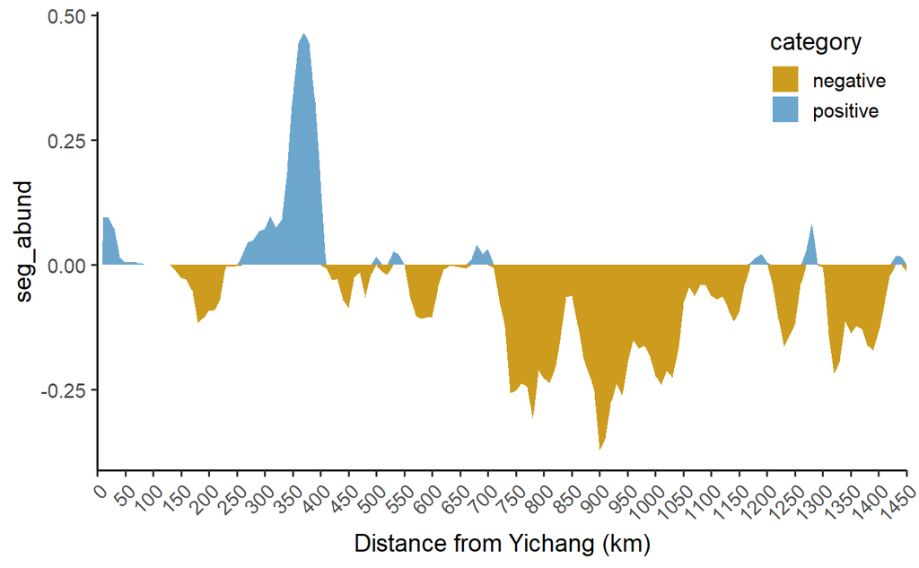

```r
ggplot(comb_df, aes(x=group_levels, y=seg_abund, fill=category))+
    geom_area(linewidth = 1) +
    scale_fill_manual(values = c("goldenrod3", "skyblue3")) +
    scale_x_continuous(expand = c(0, 0), limits = c(0, 145), breaks=seq(0, 145, 5),
                       labels = seq(0, 1450, 50)) +
    labs(x = "Distance from Yichang (km)") +
    theme_classic(base_size = 14) +
    theme(axis.text.x = element_text(angle = 45, hjust = 1),
          legend.position = c(.99, .99),
          legend.justification = c("right", "top"),
          legend.box.just = "right")
```

## 2. Plot the segment-wise changing trend of the floodplain area

```r
seg_wise_floodplain_df <- read.csv(file="floodplain_area_regression_results.csv")
head(seg_wise_floodplain_df, 5)
```

|  | groups | p_value | p_cate | r_squared | slope |
| --- | --- | --- | --- | --- | --- |
| 1 | [0,10) | 0.200 | 0.2 | 0.133 | 0.014 |
| 2 | [10,20) | 0.663 | 0.663 | 0.016 | -0.007 |
| 3 | [20,30) | 0.267 | 0.267 | 0.101 | 0.004 |
| 4 | [30,40) | 0.317 | 0.317 | 0.083 | 0.008 |
| 5 | [40,50) | 0.000 | <0.01 | 0.758 | -0.047 |

```r
group_lvls <- seg_wise_floodplain_df$groups
floodplain_df <- seg_wise_floodplain_df %>%
    mutate(groups = factor(groups, levels=group_lvls)) %>%
    mutate(group_levels = as.numeric(groups)) %>%
    mutate(flp_area_trend = case_when((p_value < 0.05 & slope < 0) ~ "decreased",
                                TRUE ~ "stable")) %>%
    mutate(flp_area_trend = factor(flp_area_trend,
                                    levels = c("decreased", "stable")))
head(floodplain_df, 5)
```

|  | groups | p_value | p_cate | r_squared | slope | group_levels | flp_area_trend |
| --- | --- | --- | --- | --- | --- | --- | --- |
| 1 | [0,10) | 0.200 | 0.2 | 0.133 | 0.014 | 1 | stable |
| 2 | [10,20) | 0.663 | 0.663 | 0.016 | -0.007 | 2 | stable |
| 3 | [20,30) | 0.267 | 0.267 | 0.101 | 0.004 | 3 | stable |
| 4 | [30,40) | 0.317 | 0.317 | 0.083 | 0.008 | 4 | stable |
| 5 | [40,50) | 0.000 | <0.01 | 0.758 | -0.047 | 5 | decreased |

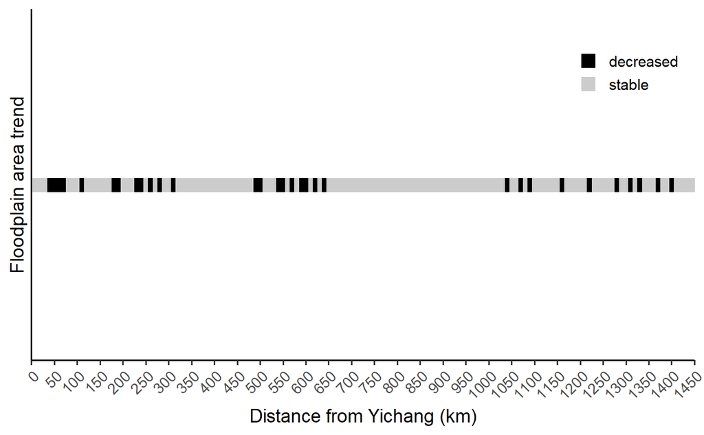

```r
floodplain_plot <- ggplot(floodplain_df, aes(
        x=group_levels, y=1, color=flp_area_trend, fill=flp_area_trend)) +
    geom_point(shape=22, size=5)+
    scale_color_manual(values = c("black", "grey80"))+
    scale_fill_manual(values = c("black", "grey80")) +
    scale_x_continuous(expand = c(0, 0), limits = c(0, 145), breaks=seq(0, 145, 5),
                       labels = seq(0, 1450, 50)) +
    scale_y_continuous(expand = c(0, 1), limits = NULL, breaks = NULL) +
    labs(x = "Distance from Yichang (km)",
         y = "Floodplain area trend") +
    guides(fill=guide_legend(""), color=guide_legend("")) +
    theme_classic(base_size = 14) +
    theme(axis.text.x = element_text(angle = 45, hjust = 1),
          legend.position = c(.99, .99),
          legend.justification = c("right", "top"),
          legend.box.just = "right")

floodplain_plot
```

## 3. Plot the segment-wise changing trend of the cropland%

```r
seg_wise_cropland_df <- read.csv(file="cropland_perc_regression_results.csv")
head(seg_wise_cropland_df, 5)
```

|  | groups | p_value | p_cate | r_squared | slope |
| --- | --- | --- | --- | --- | --- |
| 1 | [0,10) | 0.041 | <0.05 | 0.303 | -0.012 |
| 2 | [10,20) | 0.016 | <0.05 | 0.393 | 0.024 |
| 3 | [20,30) | 0.001 | <0.01 | 0.599 | 0.031 |
| 4 | [30,40) | 0.003 | <0.01 | 0.527 | 0.024 |
| 5 | [40,50) | 0.000 | <0.01 | 0.944 | 0.055 |

```r
cropland_df <- seg_wise_cropland_df %>%
    mutate(groups = factor(groups, levels=group_lvls)) %>%
    mutate(group_levels = as.numeric(groups)) %>%
    mutate(crop_perc_trend = case_when((p_value < 0.05 & slope > 0) ~ "increased",
                             TRUE ~ "stable")) %>%
    mutate(crop_perc_trend = factor(crop_perc_trend,
                                    levels = c("increased", "stable")))
head(cropland_df, 5)
```

|  | groups | p_value | p_cate | r_squared | slope | group_levels | crop_perc_trend |
| --- | --- | --- | --- | --- | --- | --- | --- |
| 1 | [0,10) | 0.041 | <0.05 | 0.303 | -0.012 | 1 | stable |
| 2 | [10,20) | 0.016 | <0.05 | 0.393 | 0.024 | 2 | increased |
| 3 | [20,30) | 0.001 | <0.01 | 0.599 | 0.031 | 3 | increased |
| 4 | [30,40) | 0.003 | <0.01 | 0.527 | 0.024 | 4 | increased |
| 5 | [40,50) | 0.000 | <0.01 | 0.944 | 0.055 | 5 | increased |

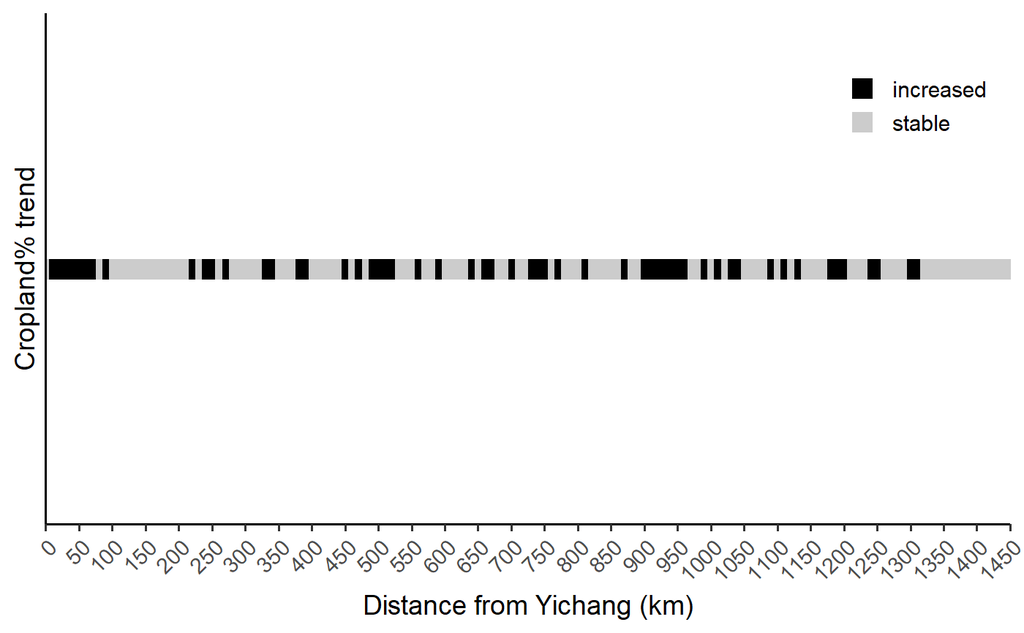

```r
cropland_plot <- ggplot(cropland_df , aes(
        x=group_levels, y=1, color=crop_perc_trend, fill=crop_perc_trend)) +
    geom_point(shape=22, size=5)+
    scale_color_manual(values = c("black", "grey80"))+
    scale_fill_manual(values = c("black", "grey80")) +
    scale_x_continuous(expand = c(0, 0), limits = c(0, 145), breaks=seq(0, 145, 5),
                       labels = seq(0, 1450, 50)) +
    scale_y_continuous(expand = c(0, 1), limits = NULL, breaks = NULL) +
    labs(x = "Distance from Yichang (km)",
         y = "Cropland% trend") +
    guides(fill=guide_legend(""), color=guide_legend("")) +
    theme_classic(base_size = 14) +
    theme(axis.text.x = element_text(angle = 45, hjust = 1),
          legend.position = c(.99, .99),
          legend.justification = c("right", "top"),
          legend.box.just = "right")
cropland_plot
```

## 4. Plot the segment-wise urban development levels

We grouped the “developed” and the “highly developed” as one category as “developed”, representing those river segments with relatively large urban% and large increment in urban% (see Appendix S3 for more details).

```r
seg_wise_urban_df <- read.csv(file="urban_cluster_results.csv")
head(seg_wise_urban_df, 5)
```

|  | groups | intl | increment | incre_perc | development_levels |
| --- | --- | --- | --- | --- | --- |
| 1 | [0,10) | 0.25474049 | 0.01845103 | 0.06753882 | less-developed |
| 2 | [10,20) | 0.13140392 | 0.06991328 | 0.34727923 | less-developed |
| 3 | [20,30) | 0.08342079 | 0.03018182 | 0.26567891 | less-developed |
| 4 | [30,40) | 0.05295352 | 0.01665948 | 0.23931563 | less-developed |
| 5 | [40,50) | 0.04399488 | 0.04033843 | 0.47832147 | fast-developing |

```r
urban_df <- seg_wise_urban_df %>%
    mutate(groups = factor(groups, levels=group_lvls)) %>%
    mutate(group_levels = as.numeric(groups)) %>%
    filter(group_levels <= 145) %>%
    droplevels() %>%
    mutate(urban_levels = case_when(
       development_levels=="less-developed" ~ "Less developed",
       development_levels=="fast-developing" ~ "Fast developing",
       TRUE ~ "Developed")) %>%
    mutate(urban_levels = factor(urban_levels,
       levels = c("Developed", "Fast developing", "Less developed")))
head(urban_df, 5)
```

|  | groups | intl | increment | incre_perc | development_levels | group_levels | urban_levels |
| --- | --- | --- | --- | --- | --- | --- | --- |
| 1 | [0,10) | 0.25474049 | 0.01845103 | 0.06753882 | less-developed | 1 | Less developed |
| 2 | [10,20) | 0.13140392 | 0.06991328 | 0.34727923 | less-developed | 2 | Less developed |
| 3 | [20,30) | 0.08342079 | 0.03018182 | 0.26567891 | less-developed | 3 | Less developed |
| 4 | [30,40) | 0.05295352 | 0.01665948 | 0.23931563 | less-developed | 4 | Less developed |
| 5 | [40,50) | 0.04399488 | 0.04033843 | 0.47832147 | fast-developing | 5 | Fast developing |

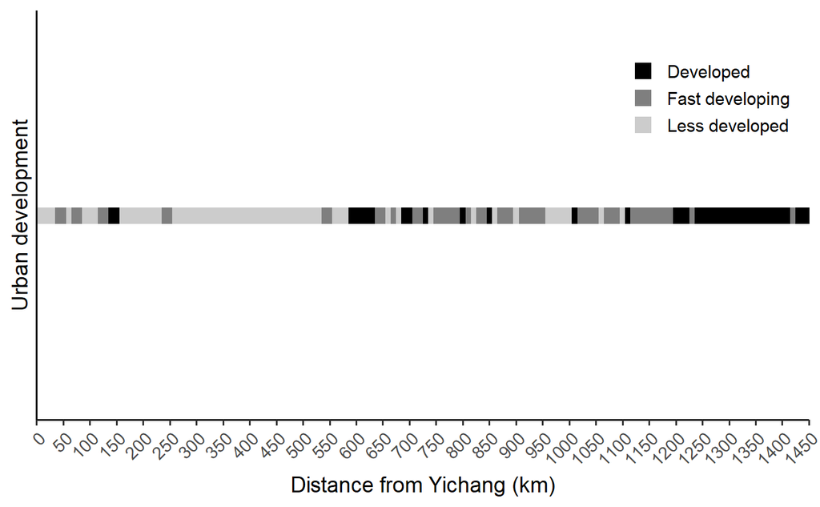

```r
urban_plot <- ggplot(urban_df, aes(
        x=group_levels, y=1, color=urban_levels, fill=urban_levels)) +
    geom_point(shape=22, size=5)+
    scale_color_manual(values = c("black", "grey50", "grey80"))+
    scale_fill_manual(values = c("black", "grey50", "grey80")) +
    scale_x_continuous(expand = c(0, 0), limits = c(0, 145), breaks=seq(0, 145, 5),
                       labels = seq(0, 1450, 50)) +
    scale_y_continuous(expand = c(0, 1), limits = NULL, breaks = NULL) +
    labs(x = "Distance from Yichang (km)",
         y = "Urban development") +
    guides(fill=guide_legend(""), color=guide_legend("")) +
    theme_classic(base_size = 14) +
    theme(axis.text.x = element_text(angle = 45, hjust = 1),
          legend.position = c(.99, .99),
          legend.justification = c("right", "top"),
          legend.box.just = "right")

urban_plot
```

```r
gap_shishou <- c(4: 27)
recover_jjm <- c(28: 53)
gap_wuhan <- c(54: 66)
continue_large <- c(67: 110)
new_gap_tongling <- c(111: 115)
steady_nanjing <- c(116: 133)
new_gap2 <- c(134: 139)
continue_zhenjiang <- c(140: 144)

feature_list <- list(gap_shishou, recover_jjm, gap_wuhan, continue_large,
                  new_gap_tongling, steady_nanjing, new_gap2, continue_zhenjiang)
```

```r
library("scales")
flp_perc_list <- list()

for (i in 1: length(feature_list)) {
    flp_perc_list[[i]] <- floodplain_df %>%
                          filter(group_levels %in% feature_list[[i]]) %>%
                          pull(flp_area_trend) %>%
                          summary()
}

flp_perc_df <- as.data.frame(do.call(rbind, flp_perc_list)) %>%
    mutate(decrease_perc = scales::percent(decreased/(decreased + stable)))
flp_perc_df
```

| decreased | stable | decrease_perc |
| --- | --- | --- |
| 10 | 14 | 41.7% |
| 4 | 22 | 15.4% |
| 7 | 6 | 53.8% |
| 3 | 41 | 6.8% |
| 0 | 5 | 0.0% |
| 4 | 14 | 22.2% |
| 2 | 4 | 33.3% |
| 1 | 4 | 20.0% |

```r
crop_perc_list <- list()

for (i in 1: length(feature_list)) {
    crop_perc_list[[i]] <- cropland_df %>%
                          filter(group_levels %in% feature_list[[i]]) %>%
                          pull(crop_perc_trend) %>%
                          summary()
}

crop_perc_df <- as.data.frame(do.call(rbind, crop_perc_list)) %>%
    mutate(increase_perc = scales::percent(increased/(increased + stable)))
crop_perc_df
```

| increased | stable | increase_perc |
| --- | --- | --- |
| 9 | 15 | 37.5% |
| 11 | 15 | 42.3% |
| 3 | 10 | 23.1% |
| 21 | 23 | 47.7% |
| 2 | 3 | 40.0% |
| 7 | 11 | 38.9% |
| 0 | 6 | 0.0% |
| 0 | 5 | 0.0% |

```r
urban_perc_list <- list()

for (i in 1: length(feature_list)) {
    urban_perc_list[[i]] <- urban_df %>%
                          filter(group_levels %in% feature_list[[i]]) %>%
                          pull(urban_levels) %>%
                          summary()
}

urban_perc_df <- as.data.frame(do.call(rbind, urban_perc_list))
colnames(urban_perc_df) <- c("developed", "fast_dev", "less_dev")

urban_perc_df <- urban_perc_df %>%
    mutate(developed_perc = scales::percent(developed/(developed + fast_dev + less_dev))) %>%
    mutate(fast_dev_perc = scales::percent(fast_dev/(developed + fast_dev + less_dev))) %>%
    mutate(less_dev_perc = scales::percent(less_dev/(developed + fast_dev + less_dev)))

urban_perc_df
```

| developed | fast_dev | less_dev | developed_perc | fast_dev_perc | less_dev_perc |
| --- | --- | --- | --- | --- | --- |
| 2 | 8 | 14 | 8.3% | 33.33% | 58.3% |
| 0 | 0 | 26 | 0.0% | 0.00% | 100.0% |
| 5 | 4 | 4 | 38.5% | 30.77% | 30.8% |
| 6 | 26 | 12 | 13.6% | 59.09% | 27.3% |
| 1 | 3 | 1 | 20.0% | 60.00% | 20.0% |
| 12 | 6 | 0 | 66.7% | 33.33% | 0.0% |
| 6 | 0 | 0 | 100.0% | 0.00% | 0.0% |
| 4 | 1 | 0 | 80.0% | 20.00% | 0.0% |